# Phenoarch platform - Cleaning procedure - Curve level using SpATS

I.Sanchez

septembre 03, 2020

# 1 Objective

```r
  library(dplyr)
  library(tidyr)
  library(openSilexStatR)
  library(ggplot2)
```

This vignette deals with the detection of outlier plants in a lattice experiment using a spatial model using splines (**SpATS** library) [3]. Here the following steps of this procedure developed for Maize experiment but easily adaptable to others species:

- From a temporal dataset designed as **plant1** with biomass (or biovolume) and plant height phenotypes. Extract predictions of these two phenotypes at a specific time point (for example just before the treatment) and create a dataset designed as **plant4**. Here, we will use the biomass and plant height predicted at 24 days at 20°C.
- From a temporal dataset of count of number of leaves, extract the phyllocron (slope of linear regression for each plant)

We so have a dataset with one row for each plant in the experiment containing the three phenotypes: **biomass24**, **PH24** and **Phy**.

- Apply a SpATS model on each phenotype, check the diagnostic graphics and retrieve the deviance residuals calculated by the model.
- On the residuals, we can detect outlier plant(s) with a combined physiological criterion applying the following rules:
- **raw procedure**: at a threshold=0.95 (can be modified)
  - **small plants** are identified if $res_i < \mu_{res} - qnorm(threshold) \times sd_{res}$ for biomass AND phyllocron
  - **big plants** are identified if $res_i > \mu_{res} + qnorm(threshold) \times sd_{res}$ for biomass AND plant height

Use the `FuncDetectOutlierPlanMaize()` and `plotDetectOutlierPlantMaize()` functions to do the previous steps.

# 2 Import of data

In this vignette, we use a toy data set of the *openSilexStatR* library (anonymized real data set).

This data set was obtained from an experiment of maize performed in the Phenoarch greenhouse composed of a conveyor belt structure of 28 lanes carrying 60 carts with one pot each (i.e. 1680 pots) (Cabrera-Bosquet et al. 2016). The data contains one experiment with 90 genotypes (Genotype) from two genotypic panels (Population) and two water scenarios (Treatment): well watered (WW) and water deficit (WD).

The leaf area and the biomass of individual plants are estimated from images taken in 13 directions. Briefly, pixels extracted from RGB images are converted into biomass and leaf area using linear models derived from regression of data from multiple side view images and destructive measurements performed at different phenological stages, from 5 to 14 appeared leaves (i.e. from 15 to 50 days at 20°C after emergence). Time courses of biomass (Biomass_Estimated) and leaf area (LA_Estimated) are expressed as a function of thermal time (TT). The height of each plants (Height_Estimated) is also estimated from the pictures. The number of visible leaves (count_leaf) is counted at least once a week on each plant. To prevent errors in leaf counting, leaves 5 and 10 of each plant are marked soon after appearance. The phyllocron is calculated as the slope of the linear regression bewtween the number of leaves and the thermal time at 2017-04-27 day, before the beginning of the water deficit. The unique ID of the plant is recorded (plantId), together with the pot position in row (Row) and in column (Col).

```r
  mydata<-PAdata
  str(mydata)
```

```
## 'data.frame':    55799 obs. of  13 variables:
##  $ Time             : Factor w/ 72 levels "2017-04-13","2017-04-14",..: 2 3 4 5 6 7 8 9 10 11 ...
##  $ plantId          : Factor w/ 1671 levels "01_01","01_02",..: 1 1 1 1 1 1 1 1 1 1 ...
##  $ Genotype         : Factor w/ 90 levels "GenoA1","GenoA10",..: 39 39 39 39 39 39 39 39 39 39 ...
##  $ Treatment        : Factor w/ 2 levels "WD","WW": 1 1 1 1 1 1 1 1 1 1 ...
##  $ Population       : Factor w/ 2 levels "Panel1","Panel2": 1 1 1 1 1 1 1 1 1 1 ...
##  $ Row              : int  1 1 1 1 1 1 1 1 1 1 ...
##  $ Col              : int  1 1 1 1 1 1 1 1 1 1 ...
##  $ Biomass_Estimated: num  NA NA NA NA 1.85 ...
##  $ LA_Estimated     : num  0.00398 0.00555 0.00742 0.01089 0.01299 ...
##  $ Height_Estimated : num  120 173 242 266 249 ...
##  $ count_leaf       : num  4.2 NA NA NA NA 6.2 NA NA NA NA ...
##  $ phyllocron       : num  NA NA NA NA NA NA NA NA NA NA ...
##  $ TT               : int  104 NA NA NA NA 109 NA NA NA NA ...
```

# 3 SpATS library

## 3.1 Detection of outliers

```r
test<-FuncDetectOutlierPlantMaize(datain=mydata,dateBeforeTrt="2017-04-27",
                param1="Biomass_Estimated",param2="Height_Estimated",
                param3="phyllocron",paramGeno="Genotype",
                paramCol="Col",paramRow="Row",
                threshold=0.95,nCol=28,nRow=60,genotype.as.random=FALSE,
                timeColumn = "Time")
```

The FuncDetectOutlierPlantMaize() returns a list of 6 elements :

- outputDataframe: a dataframe with the used data set, the fitted values and residuals calculated by the models, the plants flagged as outlier
- smallOutlier: a data.frame of the **small** plants detected as outliers
- bigOutlier: a data.frame of the **big** plants detected as outliers
- m1: A list of the SpATS results for param1
- m2: A list of the SpATS results for param2
- m3: A list of the SpATS results for param3

## 3.2 Biomass

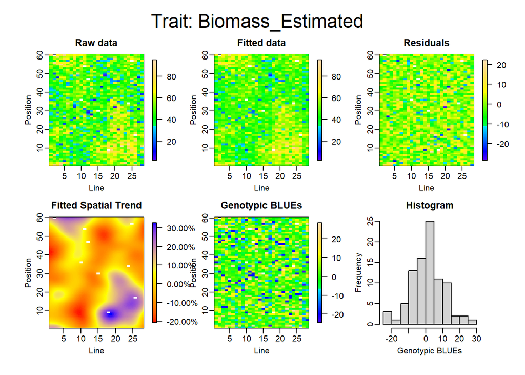

```r
  plot(test$m1, spaTrend = "percentage")
```

## 3.3 Plant height

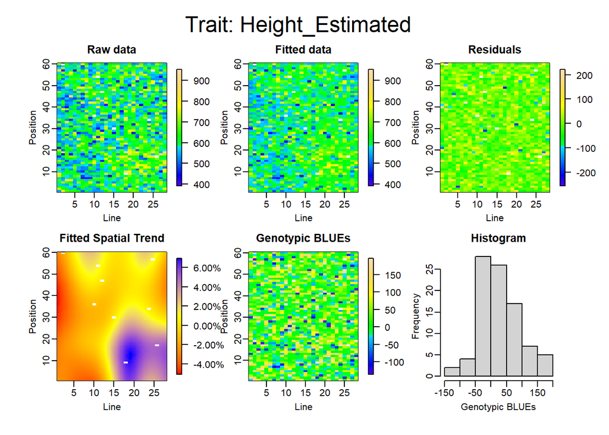

```r
  plot(test$m2, spaTrend = "percentage")
```

[figure not shown]

```r
  plot(test$m2, spaTrend = "percentage")
```

## 3.5 Diagnosis on Biomass

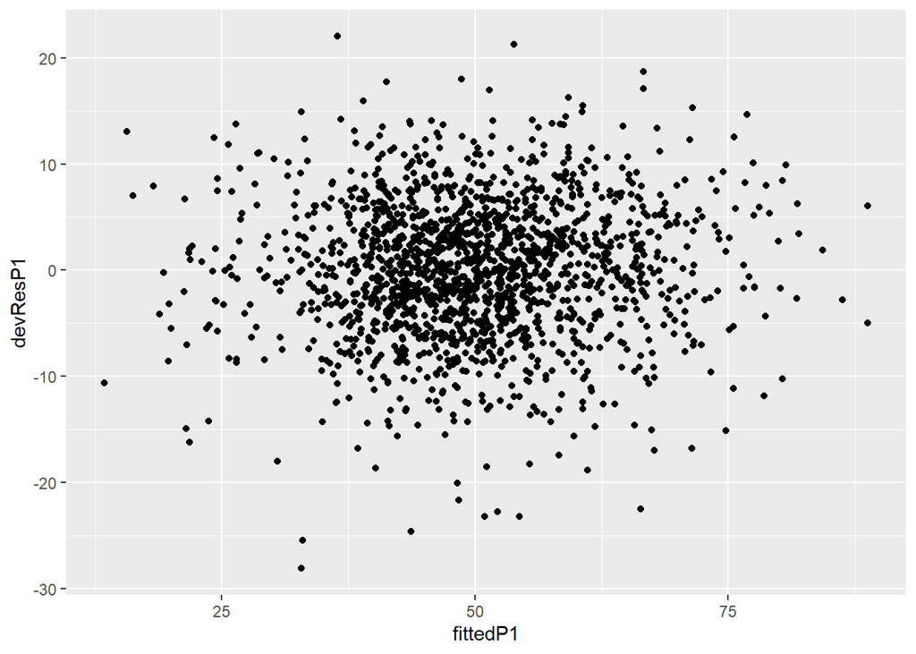

```r
ggplot(data=test$outputDataframe,aes(x=fittedP1,y=devResP1)) + geom_point()
```

# 4 Dataset highlighting the outlier plants

```r
test$smallOutlier
```

```
##          Time plantId Genotype Treatment Population Position Line
## 1  2017-04-27   05_03   GenoA6        WW     Panel1        3    5
## 2  2017-04-27   06_57  GenoA57        WW     Panel1       57    6
## 3  2017-04-27   07_02   GenoB7        WD     Panel2        2    7
## 4  2017-04-27   07_18  GenoB11        WD     Panel2       18    7
## 5  2017-04-27   09_57   GenoB3        WD     Panel2       57    9
## 6  2017-04-27   12_50  GenoA30        WD     Panel1       50   12
## 7  2017-04-27   13_28  GenoA27        WD     Panel1       28   13
## 8  2017-04-27   13_30  GenoA42        WD     Panel1       30   13
## 9  2017-04-27   14_36  GenoA17        WW     Panel1       36   14
## 10 2017-04-27   17_49  GenoB20        WD     Panel2       49   17
## 11 2017-04-27   18_15  GenoA22        WW     Panel1       15   18
## 12 2017-04-27   18_41  GenoA20        WW     Panel1       41   18
## 13 2017-04-27   21_43  GenoA18        WD     Panel1       43   21
## 14 2017-04-27   22_56   GenoA7        WW     Panel1       56   22
```

[output cut: 118 more lines]

```r
test$bigOutlier
```

```
##         Time plantId Genotype Treatment Population Position Line
## 1 2017-04-27   07_55   GenoB3        WW     Panel2       55    7
## 2 2017-04-27   11_29  GenoA36        WW     Panel1       29   11
## 3 2017-04-27   17_17  GenoB24        WW     Panel2       17   17
##   Biomass_Estimated LA_Estimated Height_Estimated count_leaf phyllocron TT  R
## 1          71.41276   0.09273917         569.7450         NA  0.3697377 NA  7
## 2          36.67895   0.06258974         704.2200         NA  0.3088115 NA 11
## 3          58.48472   0.07994443         769.4362         NA  0.3232828 NA 17
##    C devResP1 devResP2   devResP3 fittedP1 fittedP2  fittedP3   mean.devP1
## 1 55 13.80518 76.96394 0.03304748 57.60759 492.7811 0.3366902 1.240996e-14
## 2 29 12.46516 78.23241 0.01048244 24.21379 625.9876 0.2983290 1.240996e-14
## 3 17 22.03344 73.26826 0.03389641 36.45128 696.1680 0.2893864 1.240996e-14
##   sd.devP1    mean.devP2 sd.devP2   mean.devP3   sd.devP3 lower.devP1
## 1 6.413921 -1.621669e-13 44.29345 3.794596e-16 0.01446087   -10.54996
## 2 6.413921 -1.621669e-13 44.29345 3.794596e-16 0.01446087   -10.54996
## 3 6.413921 -1.621669e-13 44.29345 3.794596e-16 0.01446087   -10.54996
##   lower.devP2 lower.devP3 upper.devP1 upper.devP2 upper.devP3 lower.spatsP1
## 1   -72.85624 -0.02378602    10.54996    72.85624  0.02378602             1
## 2   -72.85624 -0.02378602    10.54996    72.85624  0.02378602             1
## 3   -72.85624 -0.02378602    10.54996    72.85624  0.02378602             1
##   lower.spatsP2 lower.spatsP3 upper.spatsP1 upper.spatsP2 upper.spatsP3
## 1             1             1             0             0             0
## 2             1             1             0             0             1
## 3             1             1             0             0             0
##   flagLowerSpats flagUpperSpats
## 1              1              0
## 2              1              0
## 3              1              0
```

The user can save the residuals and detected outliers in an output file, using `write.table()` function.

## 4.1 Plots

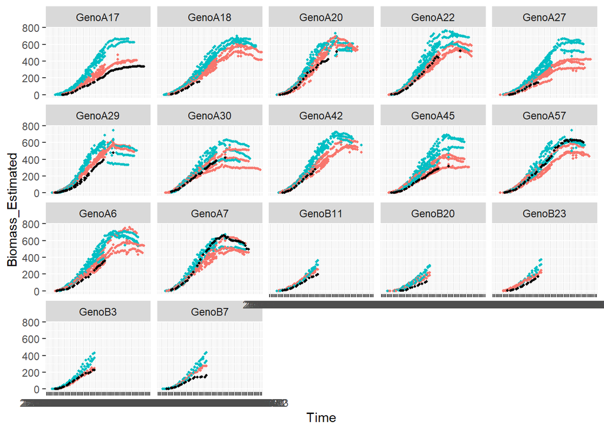

```r
plotDetectOutlierPlantMaize(datain=PAdata,
                            outmodels=test$smallOutlier,
                            x="Time",
                            y="Biomass_Estimated",
                            genotype="Genotype",
                            idColor="Treatment",
                            idFill="plantId")
```

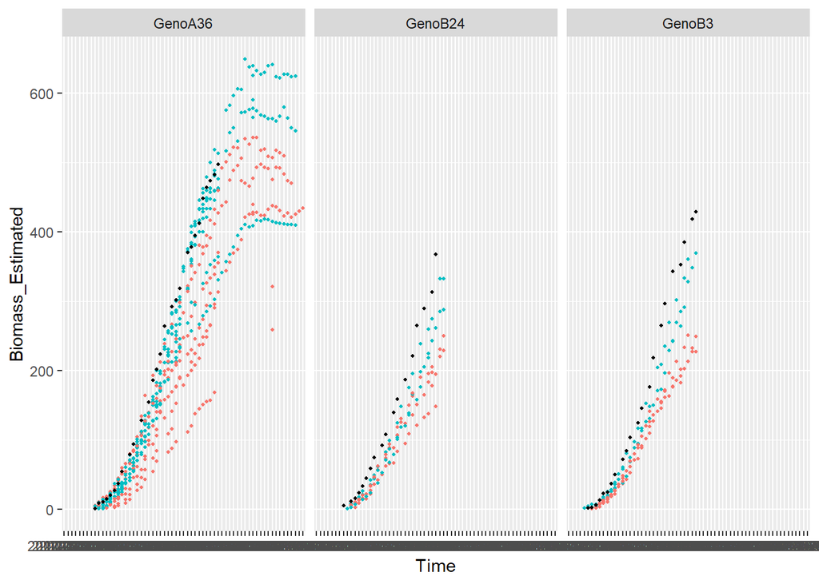

```r
plotDetectOutlierPlantMaize(datain=PAdata,
                            outmodels=test$bigOutlier,
                            x="Time",
                            y="Biomass_Estimated",
                            genotype="Genotype",
                            idColor="Treatment",
                            idFill="plantId")
```

# 6 References

1. R Development Core Team (2015). R: A language and environment for statistical computing. R Foundation for Statistical Computing, Vienna, Austria. ISBN 3-900051-07-0, URL http://www.R-project.org.
2. Maria Xose Rodriguez-Alvarez, Martin P. Boer, Fred A. van Eeuwijk, Paul H.C. Eilers (2017). Correcting for spatial heterogeneity in plant breeding experiments with P-splines. Spatial Statistics URL https://doi.org/10.1016/j.spasta.2017.10.003
3. Alvarez Prado, S., Sanchez, I., Cabrera Bosquet, L., Grau, A., Welcker, C., Tardieu, F., Hilgert, N. (2019). To clean or not to clean phenotypic datasets for outlier plants in genetic analyses?. Journal of Experimental Botany, 70 (15), 3693-3698. , DOI : 10.1093/jxb/erz191 https://prodinra.inra.fr/record/481355